# Ryan Herrschaft Final Exam

Preamble: This is Ryan Herrschaft’s final examination submission.

```r
Nola_Crime <- read_csv("C:/Users/kbernabe/Documents/sphu4160/fall_2019/exams/exam_3_R/nola_crime_2018.csv")
```

Question 1: How many observations are in the datbase? Question 2" How many variables are there? Question 3: How many unique item numbers are there in this database?

```r
describe(Nola_Crime$Item_Number)
```

```
Nola_Crime$Item_Number
       n  missing distinct
    9970        0     9384

lowest : A-00034-19 A-00128-18 A-00168-18 A-00213-18 A-00228-18
highest: X-00038-18 X-00040-18 X-00045-18 X-00051-18 X-00056-18
```

Questions 1-3: There are 9970 observations and 24 variables. There are 9384 unique item numbers.

4.) Considering only unique item numbers as crimes, how many “aggravated” crimes occured in the Irish Channel Neighborhood?

```r
Aggravated_crime_Irish <- filter(Nola_Crime, GNOCDC_LAB == "IRISH CHANNEL" & grepl('AGGRAVATED', Signal_Description))

describe(Aggravated_crime_Irish$Item_Number)
```

```
Aggravated_crime_Irish$Item_Number
         n    missing   distinct      value
         1          0          1 B-15298-18

Value      B-15298-18
Frequency           1
Proportion          1
```

There was 1 unique identifiers for an aggravated crime occuring in the Irish Channel.

5. What two neighborhoods have the largest numbers of crime reports (unique items)?

| GNOCDC_LAB | item_numbers |
| --- | --- |
| FRENCH QUARTER | 670 |
| LITTLE WOODS | 595 |
| CENTRAL BUSINESS DISTRICT | 551 |
| CENTRAL CITY | 540 |
| SEVENTH WARD | 401 |
| NA | 393 |

The French Quarter and Little Woods have the largest number of unique crime reports.

6. (10 points) Assume that the each person in the population contributes exactly one year of time at risk, calculate the rate of crime (unique items) per 1,000 persons in each neighborhood in the dataset for 2018, show this in a table in your report?

| GNOCDC_LAB | item_numbers | pop | Rate_of_Crime_per_1000 |
| --- | --- | --- | --- |
| ALGIERS POINT | 26 | 12848 | 2.023661 |
| AUDUBON | 103 | 37946 | 2.714384 |
| B. W. COOPER | 26 | 7821 | 3.324383 |
| BAYOU ST. JOHN | 45 | 19352 | 2.325341 |
| BEHRMAN | 232 | 25562 | 9.075972 |
| BLACK PEARL | 11 | 6569 | 1.674532 |

7. (15 points) What is the largest neighborhood by population in the dataset and what is its total population?

| GNOCDC_LAB | item_numbers | pop | Rate_of_Crime_per_1000 |
| --- | --- | --- | --- |
| LITTLE WOODS | 595 | 44947 | 13.237813 |
| OLD AURORA | 205 | 40130 | 5.108398 |
| AUDUBON | 103 | 37946 | 2.714384 |
| CENTRAL CITY | 540 | 35385 | 15.260704 |
| TALL TIMBERS - BRECHTEL | 217 | 35314 | 6.144872 |
| ST. ROCH | 291 | 32067 | 9.074750 |

The largest neighborhood by population is Little Woods, with a population of 44,947.

8. (10 points) What is the population size and number of unique crimes in the neighborhood with the lowest rate of crime (unique items) per 1,000 person years?

| GNOCDC_LAB | item_numbers | pop | Rate_of_Crime_per_1000 |
| --- | --- | --- | --- |
| LAKEWOOD | 10 | 13989 | 0.7148474 |
| PONTCHARTRAIN PARK | 17 | 18380 | 0.9249184 |
| LAKESHORE - LAKE VISTA | 15 | 12956 | 1.1577647 |
| FLORIDA DEV | 6 | 4976 | 1.2057878 |
| EAST CARROLLTON | 22 | 17782 | 1.2372062 |
| CITY PARK | 30 | 24140 | 1.2427506 |

Lakewood has the lowest rate of crime. There were 10 incidents of crime and the area has a population of 13,989.

9. (10 points) Calculate the rate ratio for each neighborhood for all unique crimes treating LAKE WOOD as the reference (denominator)?

| GNOCDC_LAB | item_numbers | pop | Rate_of_Crime_per_1000 | Rate_Ratio_Lakewood |
| --- | --- | --- | --- | --- |
| ALGIERS POINT | 26 | 12848 | 2.023661 | 2.830900 |
| AUDUBON | 103 | 37946 | 2.714384 | 3.797151 |
| B. W. COOPER | 26 | 7821 | 3.324383 | 4.650479 |
| BAYOU ST. JOHN | 45 | 19352 | 2.325341 | 3.252920 |
| BEHRMAN | 232 | 25562 | 9.075972 | 12.696377 |
| BLACK PEARL | 11 | 6569 | 1.674532 | 2.342503 |

10.)Calculate the rate ratio for each neighborhood for all unique “aggravated crimes” treating FRENCH QUARTER as the reference (denominator)?

| GNOCDC_LAB | item_numbers | pop | Rate_of_Crime_per_1000 | Rate_Ratio_FQ |
| --- | --- | --- | --- | --- |
| BAYOU ST. JOHN | 1 | 19352 | 0.05167425 | 0.05226678 |
| BEHRMAN | 11 | 25562 | 0.43032627 | 0.43526067 |
| BROADMOOR | 5 | 15376 | 0.32518210 | 0.32891086 |
| BYWATER | 6 | 25185 | 0.23823705 | 0.24096883 |
| CENTRAL BUSINESS DISTRICT | 10 | 18764 | 0.53293541 | 0.53904640 |
| CENTRAL CITY | 13 | 35385 | 0.36738731 | 0.37160002 |

11.) What is the most common cause for a police report to be filed (captured in the “signal description” variable) and what is the most common charge that is filed?

| Charge_Code | item_numbers |
| --- | --- |
| NA | 5151 |
| 14 67 | 602 |
| 14 62 | 425 |
| 14 56 | 355 |
| FUGITIVE ATTACHMENT | 264 |
| 14 35.3 | 200 |

12.)Calculate the rate of domestic disturbance (again based on “signal descrip- tion”) by neighborhood and show this as a table in your report.

| GNOCDC_LAB | item_numbers | pop | Rate_of_Crime_per_1000 |
| --- | --- | --- | --- |
| ALGIERS POINT | 5 | 12848 | 0.0003891656 |
| AUDUBON | 4 | 37946 | 0.0001054130 |
| B. W. COOPER | 4 | 7821 | 0.0005114435 |
| BAYOU ST. JOHN | 7 | 19352 | 0.0003617197 |
| BEHRMAN | 48 | 25562 | 0.0018777873 |
| BLACK PEARL | 2 | 6569 | 0.0003044603 |

13.) Fit a linear regression model to a summary dataset that you create which contains the rate of all crimes calculated by neighborhood as in previous calculation and includes the average age of the victims in that neighborhood as a predictor, include the summary of the regression results in your report by using the summary() function.

```r
lm_item_age<-glm(Crime_Rate_13~Victim_Age, data=data_for_lm)
```

```
Error in model.frame.default(formula = Crime_Rate_13 ~ Victim_Age, data = data_for_lm,  :
  invalid type (list) for variable 'Crime_Rate_13'
```

14.) Assume that high numbers of police reports happen in places with adequate police responsiveness but that true rates of criminal acts are similar everywhere. If this is true than the absolute numbers of crimes depend only on population size but the number of reports depends on both population size and crime rates. If these hypothesis are true, which neighborhood might have the worst police responsiveness (i.e. Low rates of crime reporting - i.e. low numbers of signals/reports and high population)?

| GNOCDC_LAB | item_numbers | pop | Police_Response |
| --- | --- | --- | --- |
| LAKEWOOD | 10 | 13989 | 0.7148474 |
| PONTCHARTRAIN PARK | 17 | 18380 | 0.9249184 |
| LAKESHORE - LAKE VISTA | 15 | 12956 | 1.1577647 |
| FLORIDA DEV | 6 | 4976 | 1.2057878 |
| EAST CARROLLTON | 22 | 17782 | 1.2372062 |
| CITY PARK | 30 | 24140 | 1.2427506 |

Lakewood possibly has the worst police response, as it has the lowest ratio of crime to population.

15.)Plot a histogram of 10,000 realizations of a Poisson distributed random variable with λ = 4.7.

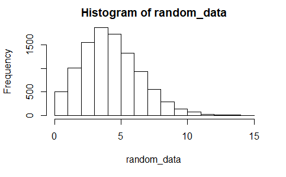

16.)Using the “iris” dataset, write a for loop that calculates the mean Sepal length for each of the species of iris and prints the results.

| mean |
| --- |
| 5.843333 |

17.) Using the “mtcars” dataset make a scatter plot of mpg vs. disp, include a regression line fit with a linear regression model or a loess smooth regression, make the color of the points different for each different number of cylinders in the engine.

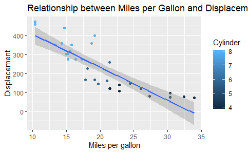

18.) Write a function to convert a vector of continuous data into its Z-scores (standard normal deviates). The formula for a Z-score is (x−μ)/σ where x is the vector of data, μ is the mean of x and σ is the standard deviation of x. Use the function to calculate the Z-scores for this vector {-4.89, -1.93, -1.11, 3.94, 0.46, -3.85, -0.20, 6.04, 9.36, 7.26, 4.88, 13.45, -2.93, 6.39, -16.22, -3.24, 6.86, 11.87, 1.81, -2.54}.

```r
head(Q_18)
```

```
               [,1]       [,2]       [,3]      [,4]
data     -4.8900000 -1.9300000 -1.1100000 3.9400000
z_scores -0.9682991 -0.5379762 -0.4187652 0.3154005
               [,5]       [,6]     [,7]      [,8]
data      0.4600000 -3.8500000 -0.20000 6.0400000
z_scores -0.1905196 -0.8171046 -0.28647 0.6206971
             [,9]     [,10]    [,11]     [,12]
data     9.360000 7.2600000 4.880000 13.450000
z_scores 1.103356 0.7980599 0.452057  1.697958
              [,13]     [,14]      [,15]      [,16]
data     -2.9300000 6.3900000 -16.220000 -3.2400000
z_scores -0.6833556 0.6715798  -2.615447 -0.7284232
             [,17]     [,18]       [,19]      [,20]
data     6.8600000 11.870000 1.810000000 -2.5400000
z_scores 0.7399081  1.468259 0.005742484 -0.6266576
```

The values, along with their z-scores, are visible above.

This is the end of the final examination.

Thank you for the class, Ryan Herrschaft.